# Risk Factor Analysis

## Outcome Variable

**Outcome Variable:** s03rec24

## Predictor Variables

**Intervention Variable:** meducyrs

**Adjustment Set:**

unadjusted

## Stratifying Variables

The analysis was stratified on these variable(s):

- studyid
- country

## Data Summary

| studyid | country | meducyrs | s03rec24 | n_cell | n |
| --- | --- | --- | --- | --- | --- |
| ki0047075b-MAL-ED | BANGLADESH | Low | 0 | 62 | 202 |
| ki0047075b-MAL-ED | BANGLADESH | Low | 1 | 3 | 202 |
| ki0047075b-MAL-ED | BANGLADESH | Medium | 0 | 58 | 202 |
| ki0047075b-MAL-ED | BANGLADESH | Medium | 1 | 3 | 202 |
| ki0047075b-MAL-ED | BANGLADESH | High | 0 | 75 | 202 |
| ki0047075b-MAL-ED | BANGLADESH | High | 1 | 1 | 202 |
| ki0047075b-MAL-ED | BRAZIL | Low | 0 | 57 | 222 |
| ki0047075b-MAL-ED | BRAZIL | Low | 1 | 3 | 222 |
| ki0047075b-MAL-ED | BRAZIL | Medium | 0 | 79 | 222 |
| ki0047075b-MAL-ED | BRAZIL | Medium | 1 | 6 | 222 |
| ki0047075b-MAL-ED | BRAZIL | High | 0 | 68 | 222 |
| ki0047075b-MAL-ED | BRAZIL | High | 1 | 9 | 222 |
| ki0047075b-MAL-ED | INDIA | Low | 0 | 71 | 216 |
| ki0047075b-MAL-ED | INDIA | Low | 1 | 4 | 216 |
| ki0047075b-MAL-ED | INDIA | Medium | 0 | 77 | 216 |
| ki0047075b-MAL-ED | INDIA | Medium | 1 | 4 | 216 |
| ki0047075b-MAL-ED | INDIA | High | 0 | 56 | 216 |
| ki0047075b-MAL-ED | INDIA | High | 1 | 4 | 216 |
| ki0047075b-MAL-ED | NEPAL | Low | 0 | 89 | 223 |
| ki0047075b-MAL-ED | NEPAL | Low | 1 | 6 | 223 |
| ki0047075b-MAL-ED | NEPAL | Medium | 0 | 73 | 223 |
| ki0047075b-MAL-ED | NEPAL | Medium | 1 | 2 | 223 |
| ki0047075b-MAL-ED | NEPAL | High | 0 | 51 | 223 |
| ki0047075b-MAL-ED | NEPAL | High | 1 | 2 | 223 |
| ki0047075b-MAL-ED | PERU | Low | 0 | 91 | 283 |
| ki0047075b-MAL-ED | PERU | Low | 1 | 8 | 283 |
| ki0047075b-MAL-ED | PERU | Medium | 0 | 94 | 283 |
| ki0047075b-MAL-ED | PERU | Medium | 1 | 4 | 283 |
| ki0047075b-MAL-ED | PERU | High | 0 | 79 | 283 |
| ki0047075b-MAL-ED | PERU | High | 1 | 7 | 283 |
| ki0047075b-MAL-ED | SOUTH AFRICA | Low | 0 | 141 | 302 |
| ki0047075b-MAL-ED | SOUTH AFRICA | Low | 1 | 5 | 302 |
| ki0047075b-MAL-ED | SOUTH AFRICA | Medium | 0 | 58 | 302 |
| ki0047075b-MAL-ED | SOUTH AFRICA | Medium | 1 | 7 | 302 |
| ki0047075b-MAL-ED | SOUTH AFRICA | High | 0 | 84 | 302 |
| ki0047075b-MAL-ED | SOUTH AFRICA | High | 1 | 7 | 302 |
| ki0047075b-MAL-ED | TANZANIA, UNITED REPUBLIC OF | Low | 0 | 64 | 209 |
| ki0047075b-MAL-ED | TANZANIA, UNITED REPUBLIC OF | Low | 1 | 0 | 209 |
| ki0047075b-MAL-ED | TANZANIA, UNITED REPUBLIC OF | Medium | 0 | 134 | 209 |
| ki0047075b-MAL-ED | TANZANIA, UNITED REPUBLIC OF | Medium | 1 | 0 | 209 |
| ki0047075b-MAL-ED | TANZANIA, UNITED REPUBLIC OF | High | 0 | 11 | 209 |
| ki0047075b-MAL-ED | TANZANIA, UNITED REPUBLIC OF | High | 1 | 0 | 209 |
| ki1000108-CMC-V-BCS-2002 | INDIA | Low | 0 | 103 | 370 |
| ki1000108-CMC-V-BCS-2002 | INDIA | Low | 1 | 3 | 370 |
| ki1000108-CMC-V-BCS-2002 | INDIA | Medium | 0 | 102 | 370 |
| ki1000108-CMC-V-BCS-2002 | INDIA | Medium | 1 | 5 | 370 |
| ki1000108-CMC-V-BCS-2002 | INDIA | High | 0 | 148 | 370 |
| ki1000108-CMC-V-BCS-2002 | INDIA | High | 1 | 9 | 370 |
| ki1000108-IRC | INDIA | Low | 0 | 138 | 410 |
| ki1000108-IRC | INDIA | Low | 1 | 9 | 410 |
| ki1000108-IRC | INDIA | Medium | 0 | 127 | 410 |
| ki1000108-IRC | INDIA | Medium | 1 | 12 | 410 |
| ki1000108-IRC | INDIA | High | 0 | 117 | 410 |
| ki1000108-IRC | INDIA | High | 1 | 7 | 410 |
| ki1000109-EE | PAKISTAN | Low | 0 | 151 | 174 |
| ki1000109-EE | PAKISTAN | Low | 1 | 0 | 174 |
| ki1000109-EE | PAKISTAN | Medium | 0 | 17 | 174 |
| ki1000109-EE | PAKISTAN | Medium | 1 | 0 | 174 |
| ki1000109-EE | PAKISTAN | High | 0 | 6 | 174 |
| ki1000109-EE | PAKISTAN | High | 1 | 0 | 174 |
| ki1017093b-PROVIDE | BANGLADESH | Low | 0 | 207 | 690 |
| ki1017093b-PROVIDE | BANGLADESH | Low | 1 | 4 | 690 |
| ki1017093b-PROVIDE | BANGLADESH | Medium | 0 | 239 | 690 |
| ki1017093b-PROVIDE | BANGLADESH | Medium | 1 | 8 | 690 |
| ki1017093b-PROVIDE | BANGLADESH | High | 0 | 222 | 690 |
| ki1017093b-PROVIDE | BANGLADESH | High | 1 | 10 | 690 |
| ki1066203-TanzaniaChild2 | TANZANIA, UNITED REPUBLIC OF | Low | 0 | 75 | 2267 |
| ki1066203-TanzaniaChild2 | TANZANIA, UNITED REPUBLIC OF | Low | 1 | 1 | 2267 |
| ki1066203-TanzaniaChild2 | TANZANIA, UNITED REPUBLIC OF | Medium | 0 | 1599 | 2267 |
| ki1066203-TanzaniaChild2 | TANZANIA, UNITED REPUBLIC OF | Medium | 1 | 1 | 2267 |
| ki1066203-TanzaniaChild2 | TANZANIA, UNITED REPUBLIC OF | High | 0 | 591 | 2267 |
| ki1066203-TanzaniaChild2 | TANZANIA, UNITED REPUBLIC OF | High | 1 | 0 | 2267 |
| ki1113344-GMS-Nepal | NEPAL | Low | 0 | 403 | 591 |
| ki1113344-GMS-Nepal | NEPAL | Low | 1 | 11 | 591 |
| ki1113344-GMS-Nepal | NEPAL | Medium | 0 | 102 | 591 |
| ki1113344-GMS-Nepal | NEPAL | Medium | 1 | 1 | 591 |
| ki1113344-GMS-Nepal | NEPAL | High | 0 | 71 | 591 |
| ki1113344-GMS-Nepal | NEPAL | High | 1 | 3 | 591 |

The following strata were considered:

- studyid: ki0047075b-MAL-ED, country: BANGLADESH
- studyid: ki0047075b-MAL-ED, country: BRAZIL
- studyid: ki0047075b-MAL-ED, country: INDIA
- studyid: ki0047075b-MAL-ED, country: NEPAL
- studyid: ki0047075b-MAL-ED, country: PERU
- studyid: ki0047075b-MAL-ED, country: SOUTH AFRICA
- studyid: ki0047075b-MAL-ED, country: TANZANIA, UNITED REPUBLIC OF
- studyid: ki1000108-CMC-V-BCS-2002, country: INDIA
- studyid: ki1000108-IRC, country: INDIA
- studyid: ki1000109-EE, country: PAKISTAN
- studyid: ki1017093b-PROVIDE, country: BANGLADESH
- studyid: ki1066203-TanzaniaChild2, country: TANZANIA, UNITED REPUBLIC OF
- studyid: ki1113344-GMS-Nepal, country: NEPAL

### Dropped Strata

Some strata were dropped due to rare outcomes:

- studyid: ki0047075b-MAL-ED, country: BANGLADESH
- studyid: ki0047075b-MAL-ED, country: BRAZIL
- studyid: ki0047075b-MAL-ED, country: INDIA
- studyid: ki0047075b-MAL-ED, country: NEPAL
- studyid: ki0047075b-MAL-ED, country: PERU
- studyid: ki0047075b-MAL-ED, country: TANZANIA, UNITED REPUBLIC OF
- studyid: ki1000108-CMC-V-BCS-2002, country: INDIA
- studyid: ki1000109-EE, country: PAKISTAN
- studyid: ki1017093b-PROVIDE, country: BANGLADESH
- studyid: ki1066203-TanzaniaChild2, country: TANZANIA, UNITED REPUBLIC OF
- studyid: ki1113344-GMS-Nepal, country: NEPAL

## Methods Detail

We’re interested in the causal parameters $E[Y_a]$ for all values of $a \in \mathcal{A}$. These parameters represent the mean outcome if, possibly contrary to fact, we intervened to set all units to have $A=a$. Under the randomization and positivity assumptions, these are identified by the statistical parameters $\psi_a=E_W[E_{Y|A,W}(Y|A=a,W)]$. In addition, we’re interested in the mean of $Y$, $E[Y]$ under no intervention (the observed mean). We will estimate these parameters by using SuperLearner to fit the relevant likelihood factors – $E_{Y|A,W}(Y|A=a,W)$ and $p(A=a|W)$, and then updating our likelihood fit using a joint TMLE.

For unadjusted analyses ($W=\{\}$), initial likelihoods were estimated using Lrnr_glm to estimate the simple $E(Y|A)$ and Lrnr_mean to estimate $p(A)$. For adjusted analyses, a small library containing Lrnr_glmnet, Lrnr_xgboost, and Lrnr_mean was used.

Having estimated these parameters, we will then use the delta method to estimate relative risks and attributable risks relative to a prespecified baseline level of $A$.

# Results Detail

## Results Plots

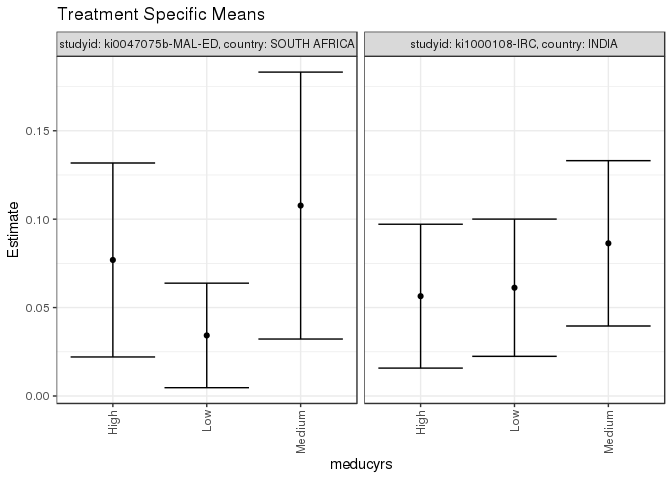

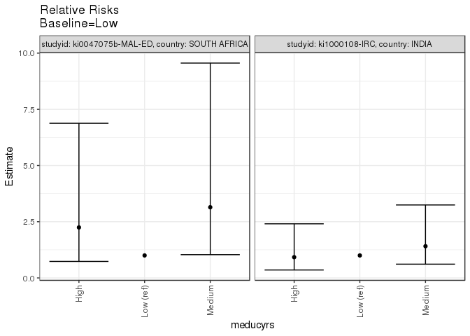

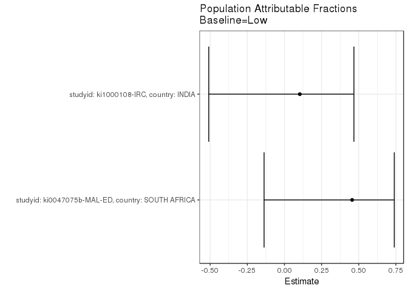

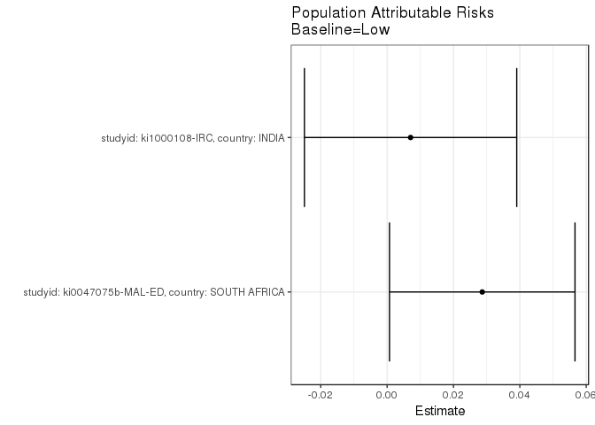

## Results Table

### Parameter: TSM

| studyid | country | intervention_level | baseline_level | estimate | ci_lower | ci_upper |
| --- | --- | --- | --- | --- | --- | --- |
| ki0047075b-MAL-ED | SOUTH AFRICA | Low | NA | 0.0342466 | 0.0046982 | 0.0637949 |
| ki0047075b-MAL-ED | SOUTH AFRICA | Medium | NA | 0.1076923 | 0.0322072 | 0.1831774 |
| ki0047075b-MAL-ED | SOUTH AFRICA | High | NA | 0.0769231 | 0.0220834 | 0.1317628 |
| ki1000108-IRC | INDIA | Low | NA | 0.0612245 | 0.0224217 | 0.1000273 |
| ki1000108-IRC | INDIA | Medium | NA | 0.0863309 | 0.0395845 | 0.1330774 |
| ki1000108-IRC | INDIA | High | NA | 0.0564516 | 0.0157803 | 0.0971229 |

### Parameter: E(Y)

| studyid | country | intervention_level | baseline_level | estimate | ci_lower | ci_upper |
| --- | --- | --- | --- | --- | --- | --- |
| ki0047075b-MAL-ED | SOUTH AFRICA | NA | NA | 0.0629139 | 0.0354838 | 0.090344 |
| ki1000108-IRC | INDIA | NA | NA | 0.0682927 | 0.0438464 | 0.092739 |

### Parameter: RR

| studyid | country | intervention_level | baseline_level | estimate | ci_lower | ci_upper |
| --- | --- | --- | --- | --- | --- | --- |
| ki0047075b-MAL-ED | SOUTH AFRICA | Low | Low | 1.000000 | 1.0000000 | 1.000000 |
| ki0047075b-MAL-ED | SOUTH AFRICA | Medium | Low | 3.144615 | 1.0346337 | 9.557591 |
| ki0047075b-MAL-ED | SOUTH AFRICA | High | Low | 2.246154 | 0.7334331 | 6.878893 |
| ki1000108-IRC | INDIA | Low | Low | 1.000000 | 1.0000000 | 1.000000 |
| ki1000108-IRC | INDIA | Medium | Low | 1.410072 | 0.6126560 | 3.245382 |
| ki1000108-IRC | INDIA | High | Low | 0.922043 | 0.3532015 | 2.407021 |

### Parameter: PAR

| studyid | country | intervention_level | baseline_level | estimate | ci_lower | ci_upper |
| --- | --- | --- | --- | --- | --- | --- |
| ki0047075b-MAL-ED | SOUTH AFRICA | Low | NA | 0.0286673 | 0.0007152 | 0.0566195 |
| ki1000108-IRC | INDIA | Low | NA | 0.0070682 | -0.0249258 | 0.0390621 |

### Parameter: PAF

| studyid | country | intervention_level | baseline_level | estimate | ci_lower | ci_upper |
| --- | --- | --- | --- | --- | --- | --- |
| ki0047075b-MAL-ED | SOUTH AFRICA | Low | NA | 0.4556597 | -0.1371408 | 0.7394286 |
| ki1000108-IRC | INDIA | Low | NA | 0.1034985 | -0.5096703 | 0.4676223 |